# act_report

Wambui Nicole

2022-09-07

# We Love Dogs Too, WeRateDogs!

For those of you who have been following our #90days of data challenge on Medium, this post marks our last (and we’d say best) entry so far. We were priviledged with being able to work with WeRateDogs on their Twitter insights for this last project.

## Background

WeRateDogs is a popular Twitter account that focuses on nothing but cute dogs, all day, every day. They decided to partner with us so that we can dig deeper into the world of twitter, doggos and of course, analytics. You can check them out on Twitter: @dogrates https://twitter.com/dog_rates or on their website https://links.weratedogs.com/.

If you check out their Twitter page, you’ll notice that most statuses are focused on one of their very good bois, (with a matching picture to verify of course), as well as a rating and short description of the good boi in question.

## Analysis

Our analysis today focuses on their engagement analytics and what we’ll call predictions. We decided to get really creative this time and decided to use some neural networks here to help predict the images that would feature on the WeRateDogs Twitter page.For our curious data enthusiasts who would like to know a little bit more about AI and neural networks, you can check out this video here https://www.youtube.com/watch?v=2-Ol7ZB0MmU.

First of all, we looked at what the highest retweet and favorite counts were, and it was a staggering `70,351` retweets and `144,286` favorites!

We were also able to figure out that both stats were related to one particular tweet:

> > Here's a doggo realizing you can stand in a pool. 13/10 enlightened af (vid by Tina Conrad) [pic.twitter.com/7wE9LTEXC4](https://t.co/7wE9LTEXC4)

> > — WeRateDogs® (@dog_rates) [June 18, 2016](https://twitter.com/dog_rates/status/744234799360020481?ref_src=twsrc%5Etfw)

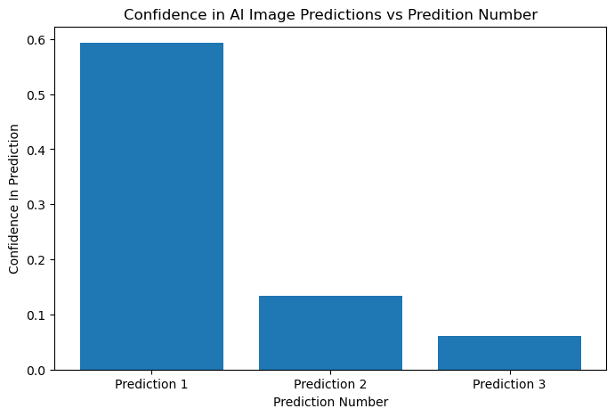

Visualisation of Prediction Confidence

What’s more, we can also see that for every prediction after the first one, the neural network got significantly less confident in it’s prediction.

We hope that these past few couple of weeks have been as exciting a journey for you as they have been for us. We thank you so much once again for joining us on this journey, giving suggestions and of course, the community we’ve managed to built in such a short period of time. We are sad it has to end, but we can guarantee you that it will not be good bye forever.

Until next time, don’t forget to be good bois!

**#90DaysofData #CoolConsultants #WeRateDogs #WhosAGoodBoi**